# Statistical inference with the GSS data

## Setup

### Load packages

```r
library(ggplot2)
library(dplyr)
library(statsr)
```

### Load data

```r
load("gss.Rdata")
```

## Part 1: Data

According to the NORC, the GSS sample is drawn using an area probability design that randomly selects respondents in households across the United States to take part in the survey. Respondents that become part of the GSS sample are from a mix of urban, suburban, and rural geographic areas.

The target population is adults (18+) living in households in the United States.

Since the samples are reasonably randomized, we could safely assume that the conclusions of this study could be generalized to the whole population.

However, this is an observational study, and not an experiment, hence causality can not be inferred from any correlation found between any of the variables. And since this was not an experiment, the question of random assignment would be irrelevant. As for sampling, it seems that it has been sufficiently randomized, as mentioned above, but it can only go as far as enabling the study conclusions to be generalizable.

## Part 2: Research question

I am interested in knowing if there is significant statistical proof of the change in people’s opinions about homosexual relationships over the turn of the century. As we all know that it seems that they are becoming more and more acceptable from what we see in the news and social media, but this dataset will provide us with statistical evidence if this is really the case.

The reason I am interested in this question is because the part of the world where I come from, there is a generally strong opposition to them. I would be interested in knowing if there is a real trend in the people’s opinions about this subject, and given the current landscape of how fast influence spreads, this could also serve as a predictor if we should expect any change here as well.

## Part 3: Exploratory data analysis

We can start with taking a look at how the population’s opinions are distributed regarding homosexual relationships.

```r
table(gss$homosex)
```

```
##
##     Always Wrong Almst Always Wrg  Sometimes Wrong Not Wrong At All
##            21601             1581             2243             7282
##            Other
##               82
```

Representing the same data visually:

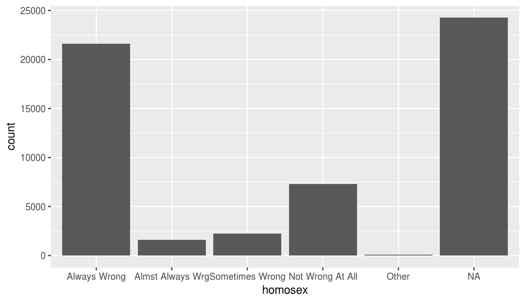

```r
ggplot(data = gss, aes(x = homosex)) + geom_bar()
```

The proportion of people who consider it unacceptable (Always wrong) and those who don’t (Not wrong at all) doesn’t seem to reflect what we know of people’s current views, as we can see that people who deem it unacceptable are signifantly more than those who don’t, so lets compare between people’s views before the turn of the 21st century and after. For this we will create another table with only the variables we are interested in, and add another one, that will indicate if the response is from the year 2000 or after, or before.

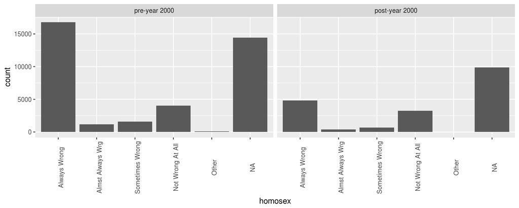

```r
relevant_data <- gss %>% select(year, homosex) %>% mutate(era = year<2000)

relevant_data$era <- ifelse(relevant_data$era==FALSE, 'post-year 2000', 'pre-year 2000')
relevant_data$era <- factor(relevant_data$era, levels = c('pre-year 2000', 'post-year 2000'))

ggplot(data = relevant_data, aes(x = homosex)) + geom_bar() + facet_grid(~ era) + theme(axis.text.x = element_text(angle = 90))
```

We can see that there has been a significant change in proportions from the pre-21st century to post.

We can also explore how these proportions have been changing over time with a graph. For this purpose I will use the proportions instead of counts, as it is clear from the side by side barplots above that the number of responses in surveys conducted before the year 2000 are significantly higher than after, since the number of years the survey was done is also significantly higher before.

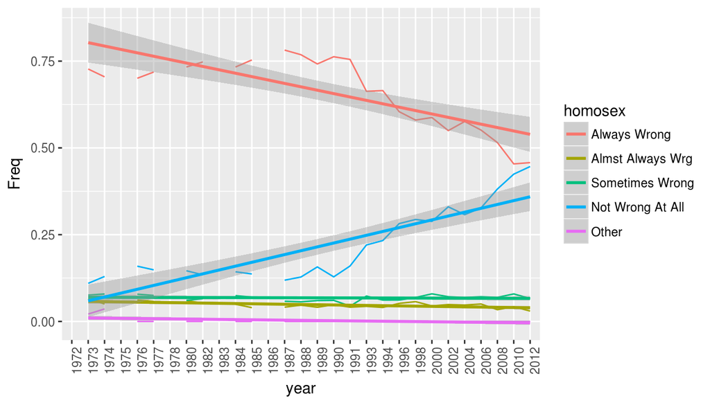

```r
propViews_byYear <- with(relevant_data, prop.table(table(homosex, year), 2))
propViews_byYear <- as.data.frame(propViews_byYear)

ggplot(propViews_byYear, aes(x = year, y = Freq, col = homosex, group = homosex)) + geom_line() + geom_smooth(method = 'lm') + theme(axis.text.x = element_text(angle = 90))
```

Now to present the changes in proportions that we are interested in, i.e. people’s opinions before and after the turn of the century.

```r
with(relevant_data, prop.table(table(homosex, era), 2))
```

```
##                   era
## homosex            pre-year 2000 post-year 2000
##   Always Wrong        0.70840893     0.52937940
##   Almst Always Wrg    0.05033543     0.04269366
##   Sometimes Wrong     0.06674824     0.07273327
##   Not Wrong At All    0.17104764     0.35519366
##   Other               0.00345977     0.00000000
```

As we can see, the proportion of people who regarded homosexual relations as ‘Always Wrong’, has fallen from 71% to 53%, whereas the proportion of people regarding them as ‘Not Wrong At All’ has risen from 17% to 36% in the sampled population.  
* * *

## Part 4: Inference

We will conduct inference of difference between proportions of two variables, i.e. both the opinions. The proportion of people who think that homosexual relations are ‘Always Wrong’ before and after the year 2000, as well as the difference in proportion of people who think that they are ‘Not Wrong At All’.

Starting with tests for proportion of people who think they are ‘Always Wrong’

#### Homosexual relations ‘Always Wrong’

The null hypothesis would be that the true proportion of people who think that homosexual relations are ‘Always Wrong’ is the same before the year 2000, and after, and the difference observed is merely due to chance, i.e. H0: p.wrong.b42k - p.wrong.aft2k = 0. The alternate hypothesis would be that there is indeed a difference between the proportion of people who think that homosexual relations are ‘Always Wrong’, i.e. Ha: p.wrong.b42k - p.wrong.aft2k != 0

Conditions: We have already assumed that the sample is random, so the observations can be treated as independant.

```r
relevant_props <- with(relevant_data, prop.table(table(homosex, era), 2))
relevant_props <- as.data.frame(relevant_props)

n_pre2k <- nrow(subset(relevant_data, era == 'pre-year 2000'))
n_post2k <- nrow(subset(relevant_data, era == 'post-year 2000'))
n_awpre2k <- nrow(subset(relevant_data, era == 'pre-year 2000' & homosex=='Always Wrong'))
n_awpost2k <- nrow(subset(relevant_data, era == 'post-year 2000' & homosex=='Always Wrong'))

p.wrong.aft2k <- relevant_props[relevant_props$homosex=='Always Wrong' & relevant_props$era=='post-year 2000',3]
p.wrong.b42k <- relevant_props[relevant_props$homosex=='Always Wrong' & relevant_props$era=='pre-year 2000',3]

point_est_aw <- p.wrong.b42k - p.wrong.aft2k

p_hat_aw <- (n_awpre2k+n_awpost2k)/nrow(relevant_data)

SEaw <- sqrt(((p_hat_aw*(1-p_hat_aw))/n_pre2k)+((p_hat_aw*(1-p_hat_aw))/n_post2k))

z_score_aw <- point_est_aw/SEaw
z_score_aw
```

```
## [1] 41.52303
```

As we can see here the z_score is pretty high, which would yield an almost zero probability of getting a sample of this size from the American population whose proportion of people who regard homosexual relations as ‘Always Wrong’ will differ from previous samples so much, had there been no difference in the actual proportion of people with such an opinion. In other words, the difference between the two proportions is too large to plausibly be due to chance, hence we will reject the null hypothesis that there has been no change in the proportion of people who believe that homosexual relations are ‘Always Wrong’, in favor of the alternate hypothesis, which is that there is indeed a difference in proportion of people with that opinion before, and after the turn of the century. We can get the p-value just for the sake of completeness:

```r
pnorm(z_score_aw, SEaw, lower.tail = F)*2
```

```
## [1] 0
```

We can also construct a confidence interval for the difference between the two proportions (the proportion of people considering homesexual relationships as ‘Always Wrong’ before, and after the year 2000). We know that the point estimate for the difference is around 18%, i.e, the proportion was higher in the past.

```r
SEaw_ci <- sqrt(((p.wrong.b42k*(1 - p.wrong.b42k))/n_pre2k)+((p.wrong.aft2k*(1 - p.wrong.aft2k))/n_post2k))

point_est_aw + c(-1, 1)*qnorm(0.975)*SEaw_ci
```

```
## [1] 0.1705835 0.1874756
```

So we are 95% confident that the proportion of people who consider homosexual relations to be ‘Always Wrong’ was 17% to 19% higher in the past than it is now.

#### Homosexual relations ‘Not Wrong At All’

The null hypothesis would be that the true proportion of people who think that homosexual relations are ‘Not Wrong At All’ is the same before the year 2000, and after, and the difference observed is merely due to chance, i.e. H0: p.notwrong.b42k - p.notwrong.aft2k = 0. The alternate hypothesis would be that there is indeed a difference between the proportion of people who think that homosexual relatins are ‘Not Wrong At All’, i.e. Ha: p.notwrong.b42k - p.notwrong.aft2k != 0

Conditions: We have already assumed that the sample is random, so the observations can be treated as independant.

Furthermore, for the success failure test, each variable has at least well above 10 observations in the sample, and even if we take the pooled proportion for the hypothesis test, the expected number is very well above 10. This means that we can assume normality of the sampling distribution and hence conduct a simple hypothesis test based on the Central Limit Theorem, i.e. we will simply extract the probability of getting this difference in proportion or higher, assuming that there is actually no difference. After that we will also extract a confidence interval for the difference in proportion.

```r
n_nwpre2k <- nrow(subset(relevant_data, era == 'pre-year 2000' & homosex=='Not Wrong At All'))
n_nwpost2k <- nrow(subset(relevant_data, era == 'post-year 2000' & homosex=='Not Wrong At All'))

p.notwrong.aft2k <- relevant_props[relevant_props$homosex=='Not Wrong At All' & relevant_props$era=='post-year 2000',3]
p.notwrong.b42k <- relevant_props[relevant_props$homosex=='Not Wrong At All' & relevant_props$era=='pre-year 2000',3]

point_est_nw <- p.notwrong.b42k - p.notwrong.aft2k

p_hat_nw <- (n_nwpre2k+n_nwpost2k)/nrow(relevant_data)

SEnw <- sqrt(((p_hat_nw*(1-p_hat_nw))/n_pre2k)+((p_hat_nw*(1-p_hat_nw))/n_post2k))

z_score_nw <- point_est_nw/SEnw
z_score_nw
```

```
## [1] -62.0847
```

```r
pnorm(z_score_aw, SEaw, lower.tail = F)*2
```

```
## [1] 0
```

```r
SEnw_ci <- sqrt(((p.notwrong.b42k*(1 - p.notwrong.b42k))/n_pre2k)+((p.notwrong.aft2k*(1 - p.notwrong.aft2k))/n_post2k))

point_est_nw + c(-1, 1)*qnorm(0.975)*SEnw_ci
```

```
## [1] -0.191939 -0.176353
```

So we are 95% confident that the proportion of people who consider homosexual relations to be ‘Not Wrong At All’ has increased by around 18% to 19%.

All this goes to show that there has indeed been a statistically significant change in the proportion of people opposing, and of those not opposing homosexual relations over time.